# Naver Webtoon EDA

NJH

2022-08-08

## Naver Webtoon Dataset에 대해 EDA를 해보겠습니다.

#### 데이터셋의 출처는 kaggle의 [Webtoon Dataset in Korean](https://www.kaggle.com/datasets/bmofinnjake/naverwebtoon-datakorean)입니다.

### 분석 환경 준비

```r
rm(list=ls())
setwd("C:/Users/NJH/Desktop/webtoon")

library(dplyr)
library(ggplot2)
library(gridExtra)
library(stringr)
library(KoNLP)
library(wordcloud)
library(RColorBrewer)
```

### 데이터 구조

##### Dataset Definition

네이버웹툰에서 서비스되는 1800편 이상의 웹툰에 대한 데이터셋입니다.

| Column name | description |
| --- | --- |
| id | unique id of the webtoon |
| title | title of the webtoon |
| author | writer of the webtoon |
| genre | genre of the webtoon |
| description | introduction of the webtoon |
| rating | average rating out of 10 for the webtoon |
| date | the most recent update date of the webtoon |
| completed | completion status |
| age | the recommended age |
| free | free service(“기다리면 무료”) event availablity |
| link | link of the webtoon |

```r
raw <- read.csv("naver.csv", header = T)
str(raw)
```

```
## 'data.frame':    1856 obs. of  11 variables:
##  $ id         : int  756056 670144 732071 703844 785701 729963 335885 675554 790239 753385 ...
##  $ title      : chr  "가난을 등에 업은 소녀" "가담항설" "가령의 정체불명 이야기" "가비지타임" ...
##  $ author     : chr  "B급달궁 / 오은지" "랑또" "가령" "2사장" ...
##  $ genre      : chr  "스토리, 로맨스" "스토리, 판타지" "옴니버스, 드라마" "스토리, 스포츠" ...
##  $ description: chr  "흔하디 흔한 재벌후계자와 캔디도 울고 갈 박복한 가난소녀의 파란만장 동거기!인기작 <다세포소녀>의 웹툰판!" "이번 주인공은 돌이다!돌이지만 동료도 모으고 악당도 물리친다!랑또 작가표 동양 판타지 소년만화" "어느 날... 인어가 내게 말을 걸어왔다. 눈을 떠보니 총구가 있었다. 그리고 몸이 연기처럼 사라지기 시작했다. 판타지"| __truncated__ "한국 최초 한국형 고교스포츠 웹툰!열혈따윈 개나 줘, 낙오자들 뿐인 농구부의 운명은?" ...
##  $ rating     : num  9.11 9.98 9.95 9.96 9.94 9.93 9.96 9.97 9.96 9.88 ...
##  $ date       : chr  "2020.10.19 00:00" "2020.10.07 23:00" "2020.02.03 23:22" "2022.05.28 22:58" ...
##  $ completed  : chr  "True" "True" "True" "False" ...
##  $ age        : chr  "전체연령가" "12세 이용가" "15세 이용가" "전체연령가" ...
##  $ free       : chr  "True" "True" "True" "False" ...
##  $ link       : chr  "https://comic.naver.com/webtoon/list?titleId=756056" "https://comic.naver.com/webtoon/list?titleId=670144" "https://comic.naver.com/webtoon/list?titleId=732071" "https://comic.naver.com/webtoon/list?titleId=703844" ...
```

id와 rating을 제외하고 모두 문자 데이터인 점을 확인했습니다.

### EDA (Exploratory Data Analysis)

정보를 갖고 있지 않다고 판단되는 id와 link를 제거하고, 데이터에 맞게 타입을 변환합니다.

```r
webtoon <- raw %>% select(-c(id,link))
webtoon$completed <- as.logical(webtoon$completed)
webtoon$free <- as.logical(webtoon$free)
```

##### 이제 각각의 column을 EDA합니다.

#### title

```r
webtoon$title %>% head(10)
```

```
##  [1] "가난을 등에 업은 소녀"  "가담항설"               "가령의 정체불명 이야기"
##  [4] "가비지타임"             "가상&RPG"               "가슴털 로망스"
##  [7] "가우스전자 시즌1~2"     "가우스전자 시즌3~4"     "가족같은 XX"
## [10] "가족의 초상"
```

“가우스전자 시즌1~2”와 “가우스전자 시즌3~4”가 나뉘어 있습니다.  
시즌이 1,2,3,4가 아니라 1~2, 3~4로 나뉘어있다는 점을 확인했으며,  
다른 시즌제 웹툰들도 살펴봅니다.(설명은 길어서 빼고 출력했습니다.)

```r
webtoon[str_count(webtoon$title, "시즌")==T,] %>% select(-description)
```

```
##                         title              author            genre rating
## 7          가우스전자 시즌1~2              곽백수     스토리, 개그   9.96
## 8          가우스전자 시즌3~4              곽백수   에피소드, 개그   9.97
## 292       놓지마 정신줄 시즌2     신태훈 / 나승훈   에피소드, 개그   9.94
## 308    닥터 프로스트 시즌 1~2              이종범 옴니버스, 드라마   9.95
## 309    닥터 프로스트 시즌 3~4              이종범   스토리, 드라마   9.97
## 375   동네변호사 조들호 시즌1              해츨링   스토리, 드라마   9.94
## 376   동네변호사 조들호 시즌2              해츨링   스토리, 드라마   8.01
## 421                레사 시즌1                POGO   스토리, 판타지   9.95
## 422              레사 시즌2~3                POGO   스토리, 판타지   9.97
## 520    모태솔로수용소 시즌2~3              석재윤   스토리, 드라마   9.93
## 851          슈퍼트리오 시즌2              황미나     스토리, 개그   7.36
## 870              스퍼맨 시즌1              하일권   스토리, 드라마   9.94
## 871              스퍼맨 시즌2              하일권 에피소드, 판타지   9.96
## 914      심연의 하늘 시즌 1~3     윤인완 / 김선희   스토리, 스릴러   9.42
```

[output cut: 35 more lines]

시즌이 나뉘어있는 기준이 확실하지 않습니다.  
시즌이 여러 개인 데이터는 title, author, genre가 중복되어 추후 분석에 문제가 될 것이라 판단했습니다.  
시즌이 통합되어야 데이터의 중복을 줄일 수 있기 때문에 나뉘어있는 행들을 합쳤습니다.

- 합친 과정은 다음과 같습니다.
  - 시즌이 넘어가며 장르가 바뀐 경우는 그 작품을 실제로 보고 판단했습니다.
  - 설명은 앞선 시즌으로 통일했습니다.
  - 평점은 평균으로, 날짜는 마지막 시즌의 날짜로 합쳤습니다.
  - 연령가는 좀 더 좁은 연령가로 처리했습니다.
  - 완결과 무료여부는 다른 행이 없었습니다.

```r
webtoon[7,]<-c("가우스전자 시즌1~4","곽백수","에피소드, 개그","다국적 문어발 기업 가우스 전자에서 벌어지는 웃픈 현실 직장인 이야기", 9.97, "2019.10.27 23:20", T, "전체연령가",F)
webtoon[8,]<-c(NA,NA,NA,NA,NA,NA,NA,NA,NA)

webtoon[308,]<-c("닥터 프로스트 시즌1~4","이종범","스토리, 드라마","당신의 마음을 읽는 천재 심리학자 닥터 프로스트. 다양한 인간 군상의 마음의 질병을 파헤치는 그의 활약이 시작된다.", 9.96, "2021.09.30 22:58", T, "15세 이용가",T)
webtoon[309,]<-c(NA,NA,NA,NA,NA,NA,NA,NA,NA)

webtoon[375,]<-c("동네변호사 조들호 시즌1~2","해츨링","스토리, 드라마","본격 생활법정만화 동네변호사 조들호", 8.98, "2017.12.27 23:19", T, "12세 이용가",F)
webtoon[376,]<-c(NA,NA,NA,NA,NA,NA,NA,NA,NA)

webtoon[421,]<-c("레사 시즌1~3","POGO","스토리, 판타지","어느날부턴가, 사람들은 디맨으로 변한다. 매일밤 계속되는 습격, 그리고 동생을 찾는 한 남자. 그 혼돈 속에서 신이 눈을 뜬다!", 9.96, "2020.11.24 23:26", T, "12세 이용가",T)
webtoon[422,]<-c(NA,NA,NA,NA,NA,NA,NA,NA,NA)

webtoon[870,]<-c("스퍼맨 시즌1~2","하일권","스토리, 드라마","사랑하는 여자친구와 드디어 첫날밤을 맞게된 김기두 갑자기 정체모를 사람들에게 납치되고 자신이 슈퍼정자를 가진 능력자라는 얘기를 듣게 되는데...", 9.95, "2020.04.07 20:45", T, "18세 이용가",T)
webtoon[871,]<-c(NA,NA,NA,NA,NA,NA,NA,NA,NA)

webtoon[914,]<-c("심연의 하늘 시즌1~5","윤인완/김선희","스토리, 스릴러","한치 앞도 보이지 않는 어둠 속 서울. 도대체 무슨 일이 벌어진 걸까?", 8.79, "2018.06.24 23:26", T, "18세 이용가",T)
webtoon[915,]<-c(NA,NA,NA,NA,NA,NA,NA,NA,NA)
webtoon[916,]<-c(NA,NA,NA,NA,NA,NA,NA,NA,NA)

webtoon[1197,]<-c("웃지 않는 개그반 시즌1~3","현용민","스토리, 개그","미친 예술고등학교 개그반에 입학한 왕진지와 그의 친구들. 그들이 겪는 웃지 못 할 이야기가 펼쳐진다.", 9.24, "2017.09.26 23:24", T, "12세 이용가",T)
webtoon[1198,]<-c(NA,NA,NA,NA,NA,NA,NA,NA,NA)

webtoon[1400,]<-c("질풍기획 시즌1~2","이현민","스토리, 개그","광고대행사 '질풍기획'의 제3기획팀. 평범한 그들의 질풍같은 하루는 오늘도 계속된다.", 9.97, "2015.06.08 23:15", T, "12세 이용가",F)
webtoon[1401,]<-c(NA,NA,NA,NA,NA,NA,NA,NA,NA)
```

이전 시즌이 없는 시즌들을 탐색해보니 제목에 “시즌”이 없어 추출되지 않았었습니다.  
하나씩 찾아 추가 전처리하여 전처리를 끝냈습니다.

```r
which(webtoon$title=="놓지마 정신줄")
```

```
## [1] 291
```

```r
which(webtoon$title=="첩보의 별")
```

```
## [1] 1440
```

```r
which(webtoon$title=="키드갱")
```

```
## [1] 1488
```

```r
which(webtoon$title=="슈퍼트리오")
```

```
## [1] 850
```

```r
which(webtoon$title=="연")
```

```
## [1] 1065
```

```r
webtoon[290,]<-c("놓지마 정신줄 시즌1~2","신태훈/나승훈","에피소드, 개그","정신, 정주리 남매와 독특한 주변 인물들의 정신줄 놓게 만드는 다양한 에피소드들! 본격 유체이탈 예방 프로젝트 '놓지마 정신줄!'", 9.93, "2019.06.14 23:19", T, "전체연령가",F)
webtoon[291,]<-c(NA,NA,NA,NA,NA,NA,NA,NA,NA)

webtoon[1430,]<-c("첩보의 별 시즌1~2","이상신/국중록","스토리, 개그","배신이 난무하는 그들의 뜨거운 우정본격 스파이 모험 만화!", 9.90, "2018.05.14 23:15", T, "전체연령가",T)
webtoon[1431,]<-c(NA,NA,NA,NA,NA,NA,NA,NA,NA)

webtoon[1478,]<-c("키드갱 시즌1~2","신영우","스토리, 개그","삼류 건달들의 좌충우돌 우왕좌왕 예측불허 육아일기. 트렌드를 이끈 정통 코믹만화의 부활! 2012년, 신영우 작가의 히트 만화 <키드갱>이 네이버 웹툰으로 다시 찾아옵니다.", 9.93, "2014.01.12 23:15", T, "12세 이용가",F)
webtoon[1479,]<-c(NA,NA,NA,NA,NA,NA,NA,NA,NA)

webtoon[846,]<-c("슈퍼트리오 시즌1~2","황미나","스토리, 개그","살아 있는 전설 황미나 작가님의 명작 '슈퍼트리오' 웹툰 리메이크로 슈퍼트리오를 다시 만나다.", 8.31, "2012.06.04 23:10", T, "12세 이용가",F)
webtoon[847,]<-c(NA,NA,NA,NA,NA,NA,NA,NA,NA)

webtoon[1065,]<-c("연 시즌1~2","구아진","옴니버스, 스릴러","'연'오늘, 지금, 당신에게도 일너어날 수 있는 일들.", 9.78, "2012.08.26 16:40", T, "12세 이용가",F)
webtoon[1066,]<-c(NA,NA,NA,NA,NA,NA,NA,NA,NA)

webtoon <- na.omit(webtoon)
```

NA를 입력하면서 데이터 타입들이 character로 변했습니다.  
다시 타입에 맞게 변환해줍니다.

```r
webtoon$rating <- as.numeric(webtoon$rating)
webtoon$completed <- as.logical(webtoon$completed)
webtoon$free <- as.logical(webtoon$free)
```

- 제목에 자주 등장한 단어 *

Nia Dictionary를 이용해 텍스트 마이닝을 시작합니다.

```r
useNIADic()
```

```
## Backup was just finished!
## 1213109 words dictionary was built.
```

```r
nouns <- extractNoun(webtoon$title)
wordcount <- table(unlist(nouns))

title_word <- as.data.frame(wordcount, stringsAsFactors = F)
title_word %>% head(10)
```

```
##      Var1 Freq
## 1       0    8
## 2      00    1
## 3       1    8
## 4      10    3
## 5   10203    1
## 6     11m    1
## 7  12차원    1
## 8      17    1
## 9      18    1
## 10    199    1
```

1글자는 단어가 안 되는 경우가 많아 2글자 이상으로 변환합니다.

```r
title_word2 <- title_word %>%
  rename(word = Var1, freq = Freq) %>%
  filter(nchar(word) >= 2)

title_word2 %>% arrange(-freq) %>% head(10)
```

```
##      word freq
## 1    우리   15
## 2    사랑   14
## 3  시즌1~   14
## 4    오늘   14
## 5    원작   12
## 6  드라마   11
## 7    루키   10
## 8    연애   10
## 9    만화    9
## 10   소년    9
```

제목에 가장 자주 등장한 단어들입니다.  
시즌1~,원작,드라마는 제목보다는 부가적 설명요소로 판단됩니다.

```r
webtoon$title[str_count(webtoon$title, "드라마원작")==T]
```

```
##  [1] "[드라마원작] 간 떨어지는..." "[드라마원작] 유미의 세포들"
##  [3] "[드라마원작] 지옥"           "[드라마원작] 모범택시"
##  [5] "[드라마원작] 스위트홈"       "[드라마원작] 치즈인더트랩"
##  [7] "[드라마원작] 알고있지만"     "[드라마원작] 쌉니다 천리..."
##  [9] "[드라마원작] 한번 더 해요"   "[드라마원작] 내 ID는 ..."
## [11] "[드라마원작] 지금 우리 ..."
```

드라마원작이 포함된 제목이 11개이므로 제목 자체에 “원작”만 들어간 횟수가 1회 존재합니다.

```r
title_word2[title_word2$word=="원작",2] <- 1
title_word2 <- title_word2 %>% filter(word!="시즌1~" & word!="드라마")

top_word_15 <- title_word2 %>%
  arrange(-freq) %>% head(15)
top_word_15
```

```
##    word freq
## 1  우리   15
## 2  사랑   14
## 3  오늘   14
## 4  루키   10
## 5  연애   10
## 6  만화    9
## 7  소년    9
## 8  결혼    7
## 9  소녀    7
## 10 리스    6
## 11 마녀    6
## 12 사람    6
## 13 용사    6
## 14 좀비    6
## 15 그녀    5
```

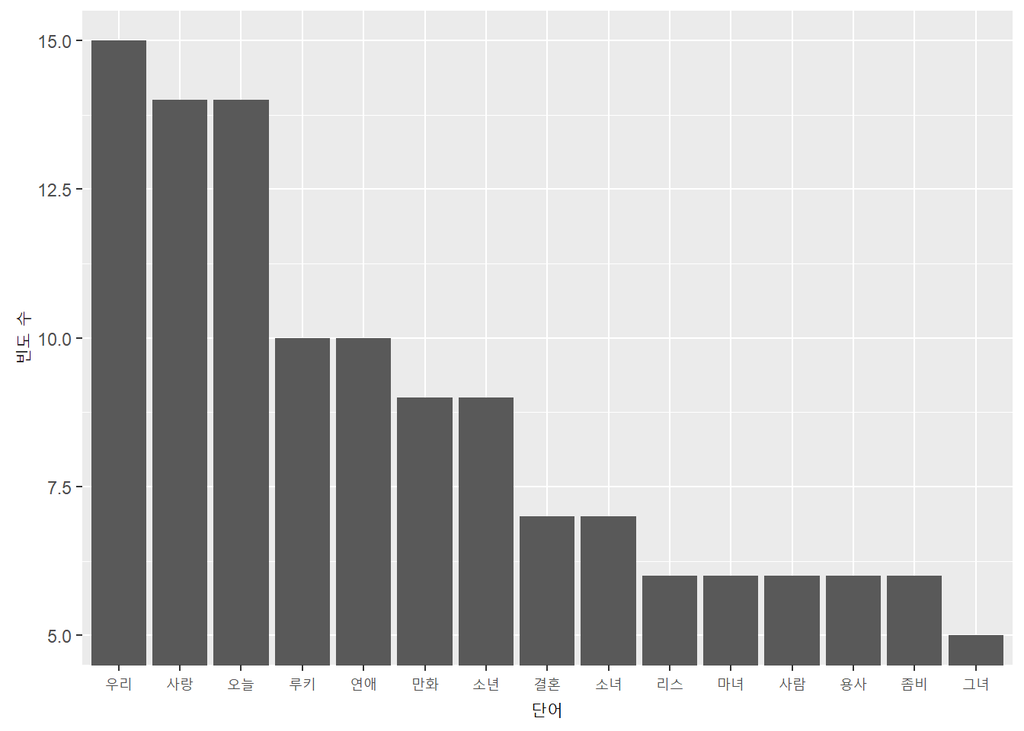

```r
ggplot(top_word_15, aes(x = reorder(word,-freq), y = freq)) +
  geom_col() + coord_cartesian(ylim = c(5, 15)) + xlab("단어") + ylab("빈도 수")
```

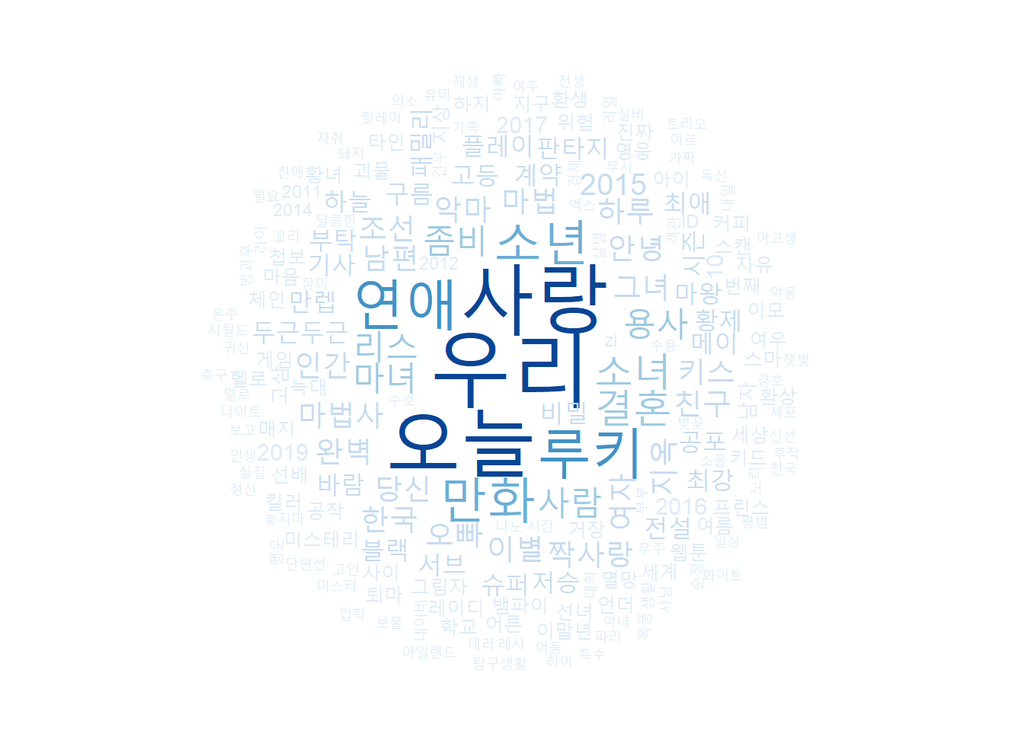

```r
pal <- brewer.pal(8, "Blues")
set.seed(700)
wordcloud(words = title_word2$word,
          freq = title_word2$freq,
          min.freq = 1,
          max.words = 200,
          random.order = F,
          scale = c(4, 0.2),
          colors = pal)
```

### description

description은 NLP를 더 공부한 후에 업데이트할 예정입니다.

### author

```r
webtoon$author %>% head(10)
```

```
##  [1] "B급달궁 / 오은지" "랑또"             "가령"             "2사장"
##  [5] "주다현"           "갸오오"           "곽백수"           "서우현"
##  [9] "김승택"           "케냠"
```

작가가 1명이 아닌 작품이 다수 존재합니다.

2명 이상일 때, /와 ,로 구분된 작가를 /로 통일하고 공백 제거합니다.

```r
webtoon$author <- str_replace_all(webtoon$author, ",", "/")
webtoon$author <- str_replace_all(webtoon$author, " ", "")

max(str_count(webtoon$author, "/"))
```

```
## [1] 3
```

```r
webtoon$author[str_count(webtoon$author,"/")==3]
```

```
## [1] "성/귤씨/토피/달로"       "타루/팀더지크/파사/화봉"
```

최대 4명의 작가가 같이 작업했다는 것을 확인했고, 전처리도 잘 되었다는 것을 확인했습니다.

str_split을 사용하여 작가를 잘라냅니다.  
list 형태로 잘라내지기 때문에 for문을 사용하여 i번째 작가를 각각 가져옵니다.

```r
author1<-c()
author2<-c()
author3<-c()
author4<-c()

for(i in 1:length(webtoon$author)){
  author1 <- c(author1, str_split(webtoon$author, "/")[[i]][1])
}

for(i in 1:length(webtoon$author)){
  author2 <- c(author2, str_split(webtoon$author, "/")[[i]][2])
}

for(i in 1:length(webtoon$author)){
  author3 <- c(author3, str_split(webtoon$author, "/")[[i]][3])
}

for(i in 1:length(webtoon$author)){
  author4 <- c(author4, str_split(webtoon$author, "/")[[i]][4])
}

author1 %>% head(10)
```

```
##  [1] "B급달궁" "랑또"    "가령"    "2사장"   "주다현"  "갸오오"  "곽백수"
##  [8] "서우현"  "김승택"  "케냠"
```

```r
author4 %>% head(10)
```

```
##  [1] NA NA NA NA NA NA NA NA NA NA
```

```r
table(author4)
```

```
## author4
## 달로 화봉
##    1    1
```

```r
webtoon <- webtoon %>% select(-author) %>% cbind(author1,author2,author3,author4)
```

author1이 잘 가져와졌음을 확인합니다.  
작가가 4명인 작품은 2개뿐이므로 author4는 대부분 NA로 가져와지는게 맞습니다.

- 평균평점이 높은 작가 *

```r
webtoon %>% group_by(author1) %>% summarise(mean_rate = mean(rating)) %>% arrange(-mean_rate)
```

```
## # A tibble: 1,197 x 2
##    author1   mean_rate
##    <chr>         <dbl>
##  1 순끼           9.98
##  2 cosmos         9.98
##  3 CRG            9.98
##  4 Croissant      9.98
##  5 QTT            9.98
##  6 구르           9.98
##  7 김성진         9.98
##  8 나윤희         9.98
##  9 도래           9.98
## 10 돌배           9.98
## # ... with 1,187 more rows
```

가장 평균평점이 높은 작가는 “순끼”입니다.  
하지만 0.005라는 근소한 차이이며, 47위까지 평균 평점이 9.98이라는 점을 감안하면 큰 의미가 없는 등수라고 판단됩니다.

```
## # A tibble: 5 x 2
##   author2 mean_rate
##   <chr>       <dbl>
## 1 MSG          9.98
## 2 김규삼       9.98
## 3 달새울       9.98
## 4 반지         9.98
## 5 수훈         9.98
```

```
## # A tibble: 5 x 2
##   author3  mean_rate
##   <chr>        <dbl>
## 1 목감기        9.98
## 2 누오바        9.97
## 3 윤이수        9.97
## 4 이른꽃        9.97
## 5 한산이가      9.97
```

2번째 작가와 3번째 작가별 평균 평점입니다.  
4번째 작가는 데이터가 2줄이므로 생략했습니다.

- 작품 수가 많은 작가 *

```r
webtoon %>% filter(author1!="웹툰작가") %>% group_by(author1) %>% summarise(n=n()) %>% arrange(-n)
```

```
## # A tibble: 1,196 x 2
##    author1     n
##    <chr>   <int>
##  1 미티       14
##  2 김규삼     11
##  3 조석       11
##  4 하일권     10
##  5 LICO        8
##  6 신의철      8
##  7 김선권      7
##  8 꼬마비      7
##  9 랑또        7
## 10 한(恨)      7
## # ... with 1,186 more rows
```

웹툰작가 콜라보 작품이 40개 존재합니다.  
단일작가를 보는 것이 목적이기에 웹툰작가를 제외했고, “미티” 작가가 14개로 작품 수가 가장 많음을 알 수 있습니다.

```
## # A tibble: 5 x 2
##   author2     n
##   <chr>   <int>
## 1 국중록      5
## 2 김인호      5
## 3 양경일      5
## 4 김선희      4
## 5 김혜진      4
```

```
## # A tibble: 5 x 2
##   author3        n
##   <chr>      <int>
## 1 김영지         2
## 2 문백경         2
## 3 싱숑           2
## 4 알파타르트     2
## 5 유진성         2
```

2번째, 3번째 작가로 갈수록 데이터 자체가 줄어 n이 작아짐을 확인할 수 있습니다.  
4번째 작가는 데이터가 2줄이므로 생략했습니다.

### genre

장르가 #과 ,로 구분되어 2개씩 들어가 있어 분리해줍니다.  
genre1은 전개방식, genre2는 장르라고 해석하겠습니다.

```r
genre1 <- c()
for(i in 1:length(webtoon$genre)){
  genre1 <- c(genre1, str_split(webtoon$genre, ", ")[[i]][1])
}

genre2 <- c()
for(i in 1:length(webtoon$genre)){
  genre2 <- c(genre2, str_split(webtoon$genre, ", ")[[i]][2])
}

table(genre1)
```

```
## genre1
##   스토리 에피소드 옴니버스
##     1544      191      107
```

```r
table(genre2)
```

```
## genre2
##      감성      개그    드라마    로맨스 무협/사극    스릴러    스포츠      액션
##        34       134       416       428        31       227        23       148
##      일상    판타지
##        75       326
```

```r
webtoon <- webtoon %>% select(-genre) %>% cbind(genre1, genre2)
```

- 전개방식별 평점, 작품 수 *

```r
webtoon_genre1 <- webtoon %>%
  group_by(genre1) %>%
  summarise(mean_rate = mean(rating), n=n()) %>%
  arrange(-n)

webtoon_genre1
```

```
## # A tibble: 3 x 3
##   genre1   mean_rate     n
##   <chr>        <dbl> <int>
## 1 스토리        9.73  1544
## 2 에피소드      9.68   191
## 3 옴니버스      9.78   107
```

```r
3088/(3088+382+214)
```

```
## [1] 0.8382193
```

스토리가 83.8%로 압도적으로 높은 비중을 차지하고 있습니다.

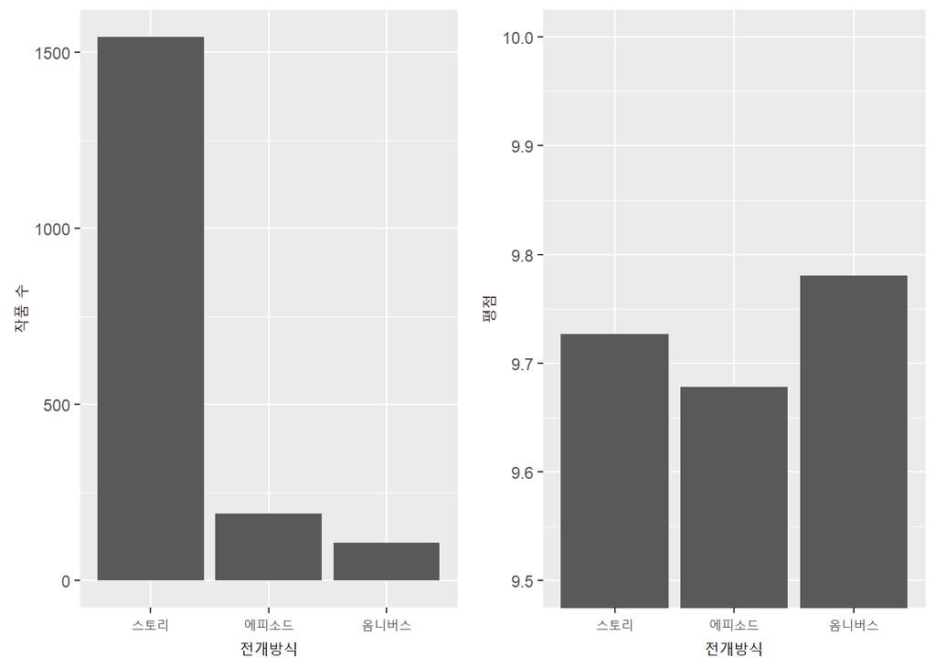

```r
n_genr1 <- ggplot(data = webtoon_genre1,
       aes(x = genre1, y = n)) + geom_col() +
        xlab("전개방식") + ylab("작품 수")

rate_genre1 <- ggplot(data = webtoon_genre1,
       aes(x = genre1, y = mean_rate)) + geom_col() +
        coord_cartesian(ylim = c(9.5, 10.0)) + xlab("전개방식") + ylab("평점")
grid.arrange(n_genr1, rate_genre1, ncol=2)
```

- 장르별 평점, 작품 수 *

```r
webtoon_genre2 <- webtoon %>%
  group_by(genre2) %>%
  summarise(mean_rate = mean(rating), n=n()) %>%
  arrange(-n)

webtoon_genre2
```

```
## # A tibble: 10 x 3
##    genre2    mean_rate     n
##    <chr>         <dbl> <int>
##  1 로맨스         9.78   428
##  2 드라마         9.77   416
##  3 판타지         9.72   326
##  4 스릴러         9.72   227
##  5 액션           9.53   148
##  6 개그           9.64   134
##  7 일상           9.65    75
##  8 감성           9.90    34
##  9 무협/사극      9.87    31
## 10 스포츠         9.54    23
```

로맨스와 드라마 장르의 작품 수가 가장 높으며, 그 다음으로 판타지 장르가 작품 수가 많습니다.  
작품 수와는 달리 평점은 감성과 무협이 가장 높습니다.

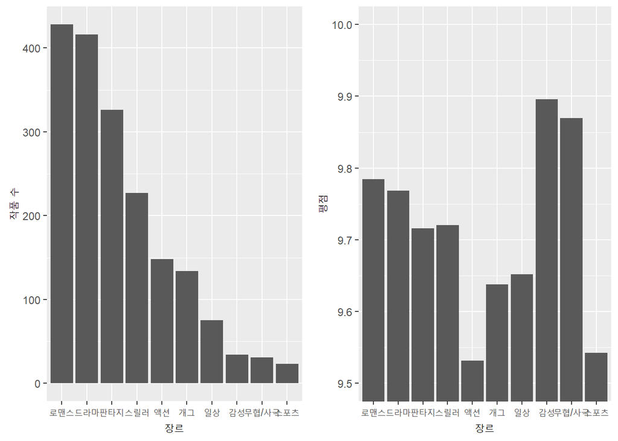

```r
n_genre2 <- ggplot(data = webtoon_genre2,
       aes(x = reorder(genre2,-n), y = n)) + geom_col() +
        xlab("장르") + ylab("작품 수")

rate_genre2 <- ggplot(data = webtoon_genre2,
       aes(x = reorder(genre2,-n), y = mean_rate)) + geom_col() +
        coord_cartesian(ylim = c(9.5, 10.0)) + xlab("장르") + ylab("평점")
grid.arrange(n_genre2, rate_genre2, ncol=2)
```

### date

```r
webtoon$date %>% head(10)
```

```
##  [1] "2020.10.19 00:00" "2020.10.07 23:00" "2020.02.03 23:22" "2022.05.28 22:58"
##  [5] "2022.06.01 22:57" "2022.01.27 22:58" "2019.10.27 23:20" "2022.06.01 22:53"
##  [9] "2020.09.28 00:00" "2022.06.07 22:53"
```

```r
webtoon$year <- str_sub(webtoon$date, 1, 4)
webtoon$year <- as.numeric(webtoon$year)

webtoon_year <- webtoon %>% group_by(year) %>% summarise(n=n())
webtoon_year
```

```
## # A tibble: 17 x 2
##     year     n
##    <dbl> <int>
##  1  2006     2
##  2  2007     4
##  3  2008    16
##  4  2009    23
##  5  2010    24
##  6  2011    41
##  7  2012    56
##  8  2013    47
##  9  2014    53
## 10  2015    72
## 11  2016    58
## 12  2017    53
## 13  2018    68
## 14  2019    97
## 15  2020   228
## 16  2021   241
## 17  2022   759
```

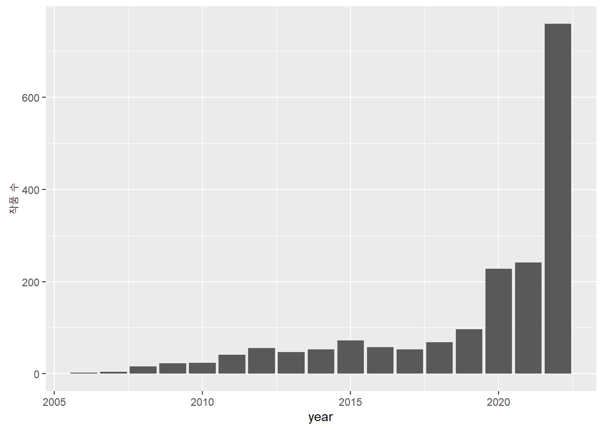

```r
ggplot(data = webtoon_year, aes(x = year, y = n)) + geom_col() +
  ylab("작품 수")
```

시간이 흐름에 따라 작품 수가 증가함을 알 수 있습니다.

### rating

```r
summary(webtoon$rating)
```

```
##    Min. 1st Qu.  Median    Mean 3rd Qu.    Max.
##   3.800   9.760   9.900   9.725   9.950   9.990
```

Q1 = 9.76, Q3 = 9.95인 것으로 보아 전체적으로 평점이 엄청 높음을 알 수 있습니다.

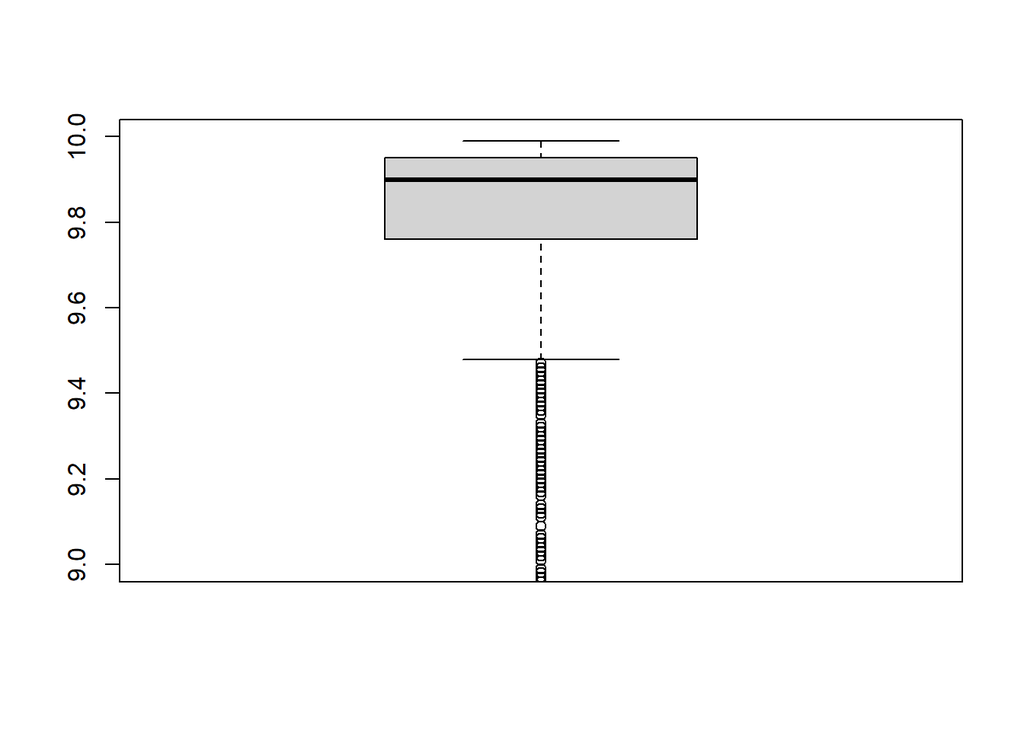

```r
boxplot(webtoon$rating, ylim = c(9,10))
```

더 자세히 볼 수 있도록 y축을 조정했습니다.

- 연도별 평점 *

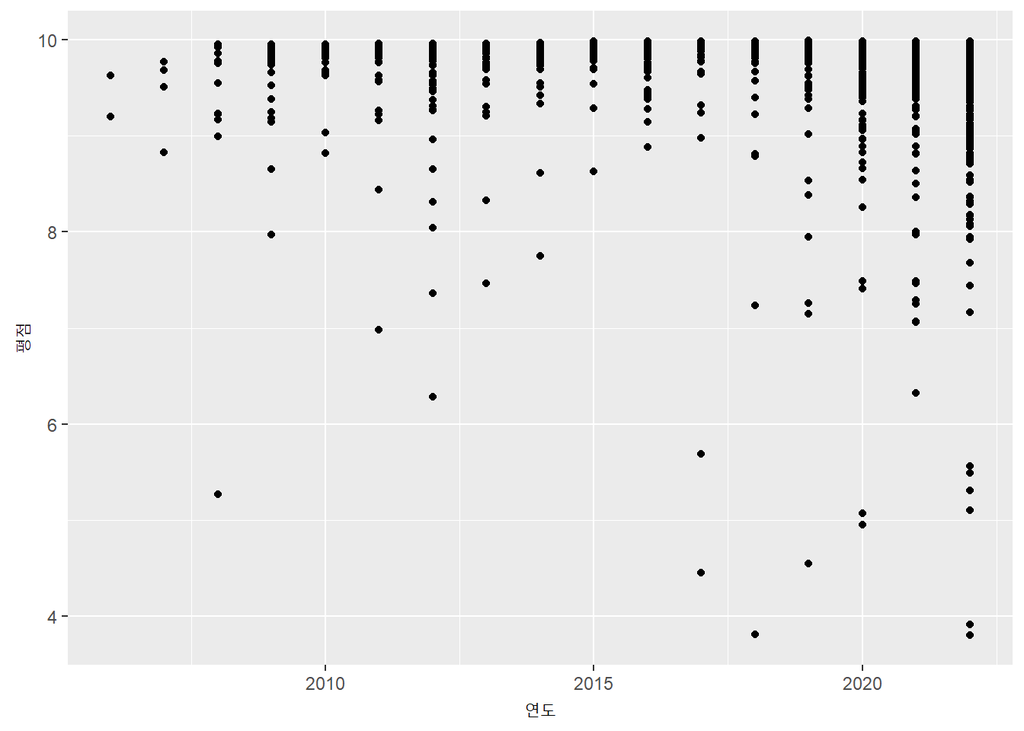

```r
ggplot(data = webtoon, aes(x = year, y = rating)) + geom_point() + xlab("연도") + ylab("평점")
```

boxplot에서도 확인했듯이 전체적인 평점이 높습니다.

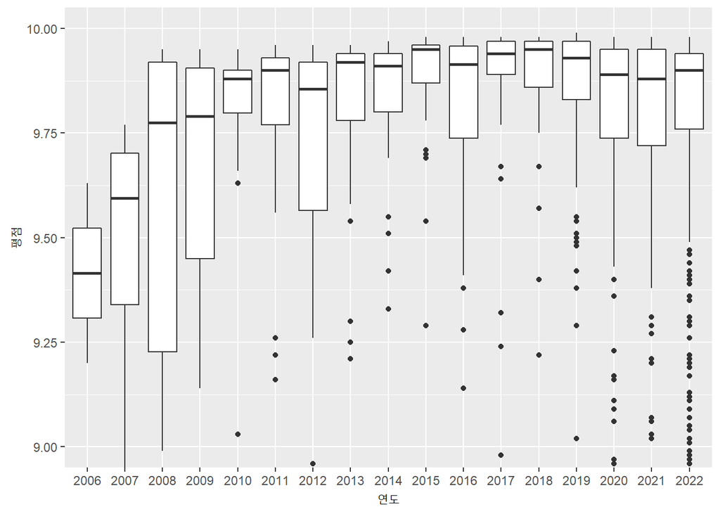

```r
ggplot(data = webtoon, aes(x = as.character(year), y = rating)) + geom_boxplot() + coord_cartesian(ylim=c(9,10)) + xlab("연도") + ylab("평점")
```

y축을 조정하여 보니 전체적으로 평점이 높지만, 그 중에서도 흐름이 변하고 있음을 확인할 수 있습니다.

- 연도별 평균 평점 *

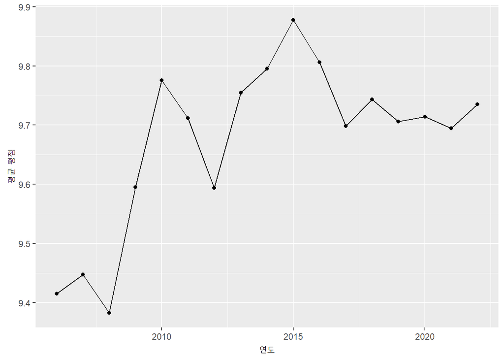

```r
rating_year <- webtoon %>% group_by(year) %>% summarise(mean_rate = mean(rating))

ggplot(data = rating_year, aes(x = year, y = mean_rate)) + geom_line() + geom_point() + xlab("연도") + ylab("평균 평점")
```

### completed

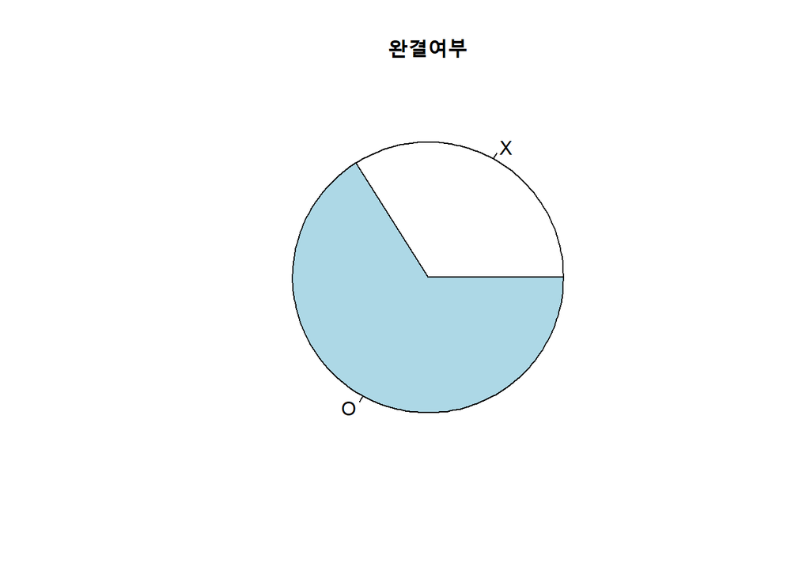

```r
pie(table(webtoon$completed), labels = c("X", "O"), main = "완결여부")
```

- 연도별 완결 작품 수 *

```r
webtoon_com_year <- webtoon %>% filter(completed == T) %>%
                        group_by(year) %>% summarise(n=n())
webtoon_com_year
```

```
## # A tibble: 17 x 2
##     year     n
##    <dbl> <int>
##  1  2006     2
##  2  2007     4
##  3  2008    16
##  4  2009    23
##  5  2010    24
##  6  2011    41
##  7  2012    56
##  8  2013    47
##  9  2014    53
## 10  2015    72
## 11  2016    58
## 12  2017    53
## 13  2018    68
## 14  2019    97
## 15  2020   228
## 16  2021   240
## 17  2022   134
```

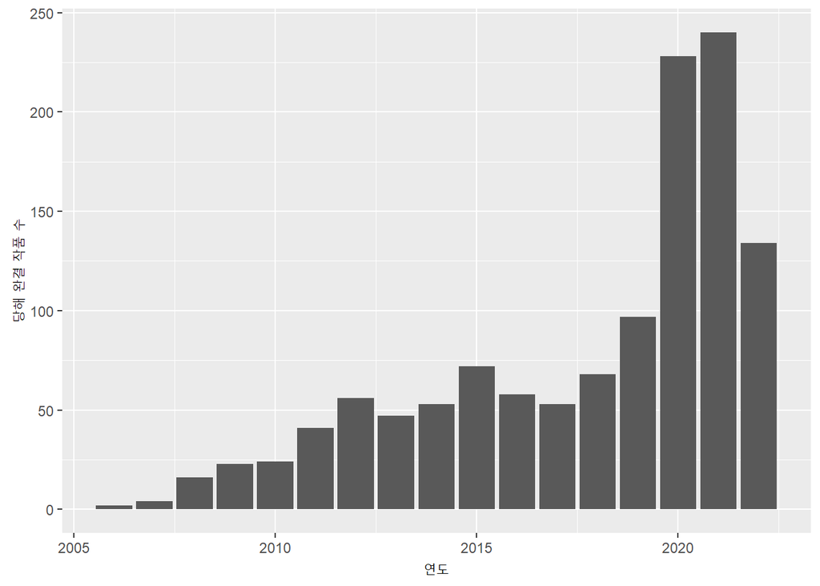

```r
ggplot(data = webtoon_com_year, aes(x = year, y = n)) + geom_col() + xlab("연도") + ylab("당해 완결 작품 수")
```

### age

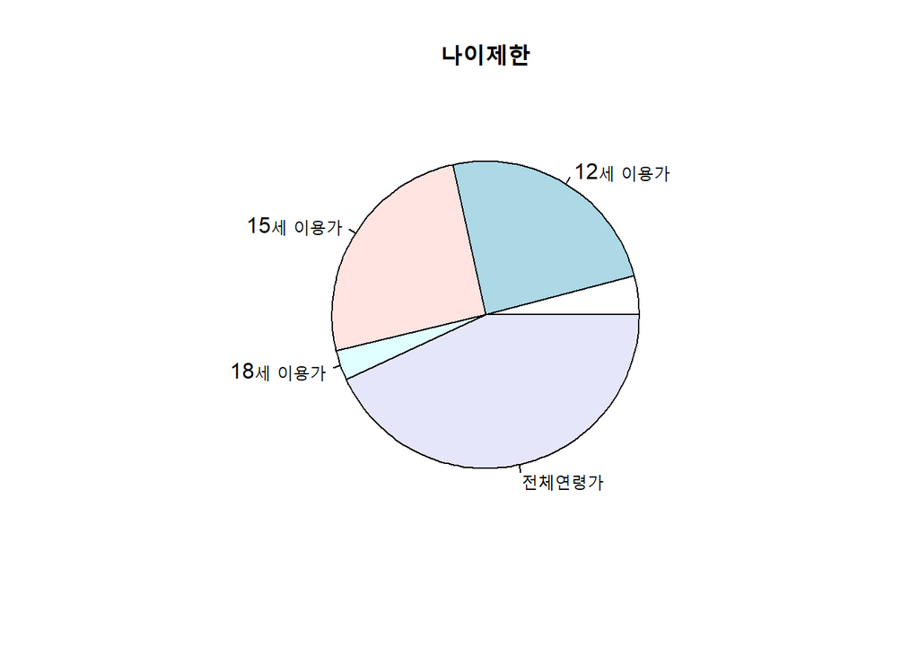

```r
pie(table(webtoon$age), main = "나이제한")
```

### free

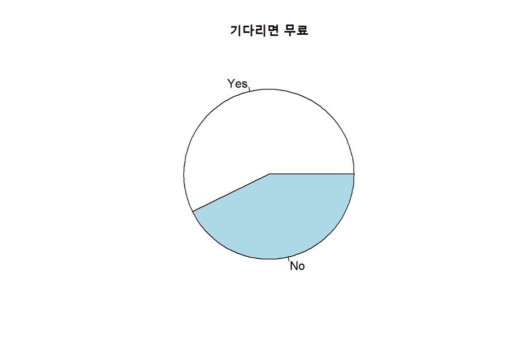

```r
pie(table(webtoon$free), labels = c("Yes","No"), main = "기다리면 무료")
```